# Презентация по лабораторной работе №2

Операционные системы

Арбатова В. П., НКАбд-01-23

Российский университет дружбы народов, Москва, Россия

# Цель работы

Изучить идеологию и применение средств контроля версий, освоить умения по работе с git

# Задание

1. Создать базовую конфигурацию для работы с git
2. Создать ключ SSH
3. Создать ключ PGP
4. Настроить подписи git
5. Зарегистрироваться на Github
6. Создать локальный каталог для выполнения заданий по предмету

# Выполнение лабораторной работы

## Базовая настройка git

Устанавливаю git, задаю имя и email владельца репозитория, настраиваю utf-8 в выводе сообщений git, задаю имя начальной ветки

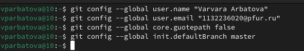

Имя, email, utf-8, имя начальной ветки

## Базовая настройка git

Устанавливаю параметры autoctlf, safecrlf

## Создание ключей SSH

По алгоритму rsa с ключём размером 4096 бит

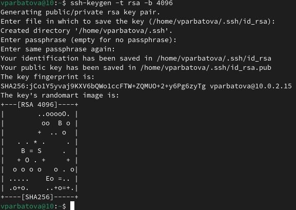

## Создание ключей SSH

По алгоритму ed25519

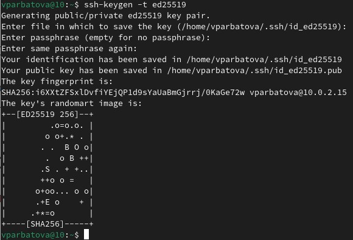

По алгоритму ed25519

## Создание ключей SSH

Копирую ssh ключ

## Создание ключей SSH

Вставляю скопированный ключ в поле для ssh ключа

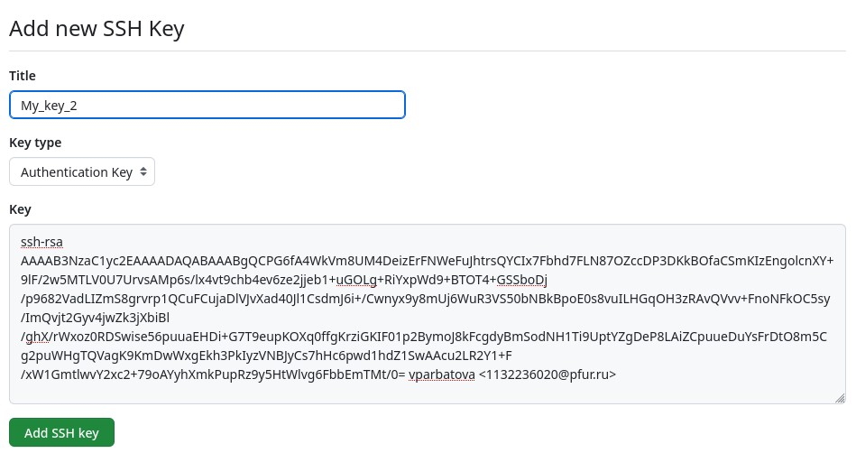

Ключ на сайте

## Создание ключей PGP

Генерирую ключ

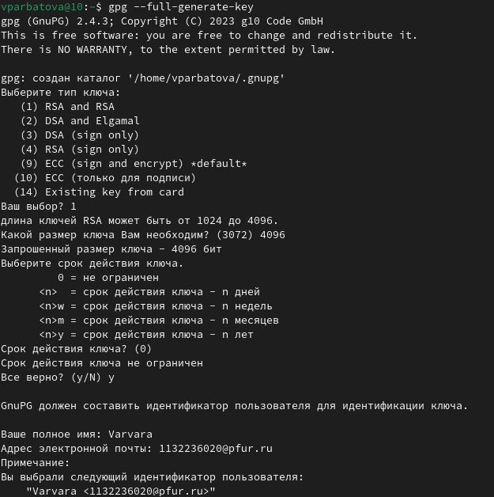

Генерирую ключ

## Создание ключей PGP

Заполняю данные, задаю пароль

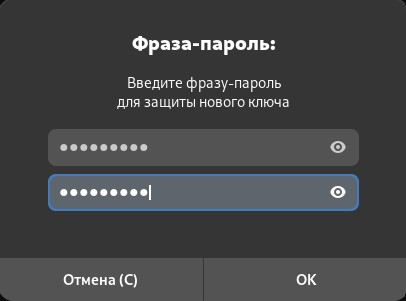

Задаю пароль

## Добавление PGP ключа в GitHub

Вывожу список ключей и копирую отпечаток приватного ключа

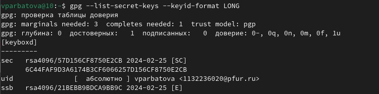

Список ключей

## Добавление PGP ключа в GitHub

Копирую сгенерированный PGP ключ в буфер обмена

## Добавление PGP ключа в GitHub

Добавляю PGP ключ на сайт

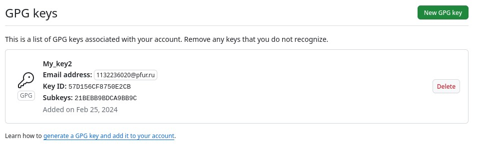

Добавленный ключ

## Добавление PGP ключа в GitHub

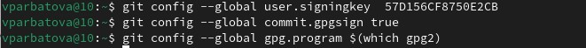

Настройка подписи коммитов

## Добавление PGP ключа в GitHub

Скачиваю gh и авторизируюсь

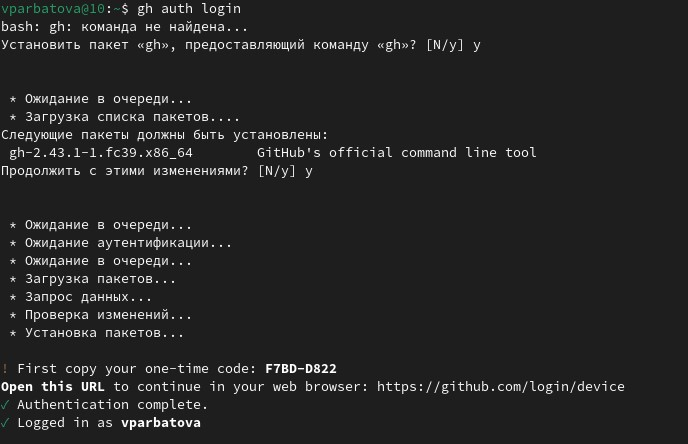

Авторизация

## Добавление PGP ключа в GitHub

Авторизировалась

[figure not shown]

Готово!

## Добавление PGP ключа в GitHub

Создаю каталог курса

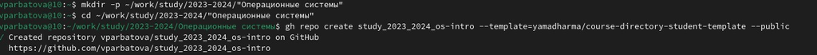

Создание каталога курса

## Добавление PGP ключа в GitHub

Клонирую репозиторий

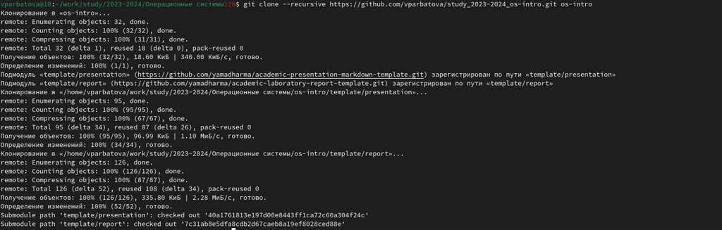

Клонирование репозитория

## Добавление PGP ключа в GitHub

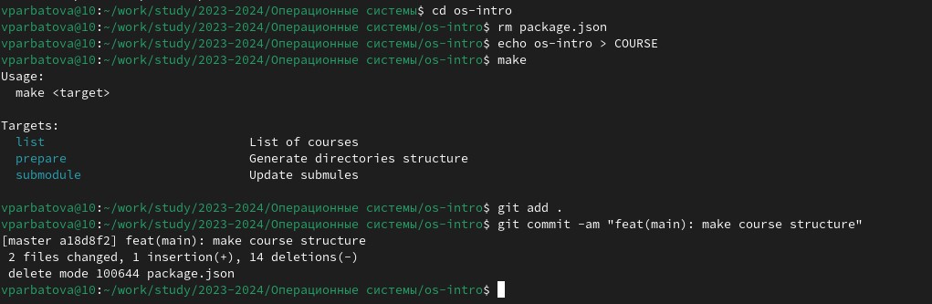

Заканчиваю настройку

# Выводы

я изучила идеологию и применение средств контроля версий, освоила умения по работе с git

# Список литературы